# Variable selection

Perry de Valpine

September 2019

# Bayesian variable selection

- You have many candidate explanatory variables.
- Bayesian approach is to have a probability that a variable is included in the model.
- Really this is a probability that the coefficient is $\ne 0$.
- BUGS/JAGS implementation is with indicator variables.
- This has problems. Let’s look at it.

# Set up a model

Use linear regression for simplicity.

- 5 “real” effects (true coefficient $\ne 0$)
- 10 null effects (true coefficient $= 0$).

### Create `nimble` model

```r
lmCode <- nimbleCode({
  psi ~ dunif(0,1)   # prior on inclusion probability
  sigma ~ dunif(0, 20)
  for(i in 1:numVars) {
    z[i] ~ dbern(psi) # indicator variable
    beta[i] ~ dnorm(0, sd = 100)
    zbeta[i] <- z[i] * beta[i]  # indicator * beta
  }
  for(i in 1:n) {
    pred.y[i] <- inprod(X[i, 1:numVars], zbeta[1:numVars])
    y[i] ~ dnorm(pred.y[i], sd = sigma)
  }
})
set.seed(1)
X <- matrix(rnorm(100*15), nrow = 100, ncol = 15)
lmConstants <- list(numVars = 15, n = 100, X = X)
lmModel <- nimbleModel(lmCode, constants = lmConstants)
```

```
## defining model...
```

```
## Adding X as data for building model.
```

```
## building model...
```

```
## setting data and initial values...
```

```
## running calculate on model (any error reports that follow may simply reflect missing values in model variables) ...
## checking model sizes and dimensions... This model is not fully initialized. This is not an error. To see which variables are not initialized, use model$initializeInfo(). For more information on model initialization, see help(modelInitialization).
## model building finished.
```

### Simulate data using `nimble` model.

```r
true_betas <- c(c(0.1, 0.2, 0.3, 0.4, 0.5),
                rep(0, 10))
lmModel$beta <- true_betas
lmModel$sigma <- 1
lmModel$z <- rep(1, 15)
lmModel$psi <- 0.5
lmModel$calculate()
```

```
## [1] NA
```

```r
set.seed(0) ## Make this reproducible
lmModel$simulate('y')
lmModel$y
```

```
##   [1]  2.093746080  0.736124260  2.027064905  1.015404063  0.084651727
##   [6] -0.102184583 -0.686491964  0.202594710  0.435718990  2.644015748
##  [11]  0.961672768 -0.360245858 -0.662667183 -1.700501339 -0.200258772
##  [16]  0.650832608  0.409270819 -1.403333432 -0.423337248 -0.174741477
##  [21]  0.487168232  0.968487430  0.202134183 -1.160597424  0.115539231
##  [26]  2.170098572 -0.003863118 -1.648798404 -2.075791272  0.033745581
##  [31] -1.531037727 -1.914773221 -1.393267801 -0.254103524  0.795219196
##  [36]  0.967671016  1.885420816 -0.908136075  1.082161648 -0.104709767
##  [41]  1.649691365  1.541881532 -0.559683516 -0.822087590 -1.913115062
##  [46] -3.954117862 -1.589976002  0.871605491  0.953431209 -0.577571628
##  [51]  1.507252727 -0.350772513  2.166512914 -2.023372326 -0.096192075
##  [56]  0.843670922 -0.154148031 -1.340666932 -3.601141277 -0.841059715
##  [61] -0.294235021  1.428815064 -0.376621679  0.447239839 -0.562541558
##  [66]  1.167947335 -1.864871858  0.412053056  0.646638107  0.038506671
##  [71] -0.111487777 -0.372454814 -1.136155107  0.759649263  0.727207754
##  [76]  0.799602352 -0.196032522  0.578105952 -0.562616047 -0.287549737
##  [81] -0.854396858  1.186251149  0.703220412 -0.991016964  1.201811830
##  [86]  0.482899480  0.260664826 -0.559752750 -0.411360653  0.722577891
##  [91]  1.076918845  0.829422515  0.045169860 -0.894457768  2.907929426
##  [96] -0.917876409  0.899026957  0.946590373  0.061559025  0.690701001
```

```r
lmModel$calculate()
```

```
## [1] -226.7382
```

```r
lmModel$setData('y')
lmData = list(y = lmModel$y)
```

# Look at `lm`

It will be helpful to refer to back simple linear regression:

```r
summary(lm(lmModel$y ~ lmModel$X))
```

```
##
## Call:
## lm(formula = lmModel$y ~ lmModel$X)
##
## Residuals:
##      Min       1Q   Median       3Q      Max
## -2.32512 -0.49673 -0.00609  0.56855  2.17110
##
## Coefficients:
##              Estimate Std. Error t value Pr(>|t|)
## (Intercept) -0.001390   0.098714  -0.014 0.988795
## lmModel$X1   0.177426   0.103873   1.708 0.091310 .
## lmModel$X2   0.123335   0.098356   1.254 0.213334
## lmModel$X3   0.356547   0.092810   3.842 0.000236 ***
## lmModel$X4   0.450670   0.097557   4.620 1.37e-05 ***
## lmModel$X5   0.414989   0.080192   5.175 1.53e-06 ***
## lmModel$X6  -0.108063   0.097754  -1.105 0.272117
## lmModel$X7   0.109590   0.086844   1.262 0.210470
## lmModel$X8  -0.064770   0.087194  -0.743 0.459658
## lmModel$X9   0.005129   0.091048   0.056 0.955214
## lmModel$X10 -0.065272   0.096850  -0.674 0.502191
## lmModel$X11  0.012760   0.090297   0.141 0.887959
## lmModel$X12  0.182145   0.092908   1.960 0.053254 .
## lmModel$X13  0.116821   0.090177   1.295 0.198706
## lmModel$X14 -0.118522   0.110125  -1.076 0.284899
## lmModel$X15  0.017310   0.096353   0.180 0.857861
## ---
## Signif. codes:  0 '***' 0.001 '**' 0.01 '*' 0.05 '.' 0.1 ' ' 1
##
## Residual standard error: 0.8874 on 84 degrees of freedom
## Multiple R-squared:  0.5416, Adjusted R-squared:  0.4597
## F-statistic: 6.616 on 15 and 84 DF,  p-value: 4.146e-09
```

# Look at JAGS

### Rewrite model to be JAGS-compatible

```r
## Switch from normal with sd to normal with precision:
lmCodeJAGS <- nimbleCode({
  psi ~ dunif(0,1)   # prior on inclusion probability
  sigma ~ dunif(0, 20)
  tau <- 1/(sigma*sigma)
  for(i in 1:numVars) {
    z[i] ~ dbern(psi) # indicator variable
    beta[i] ~ dnorm(0, 1e-4)
    zbeta[i] <- z[i] * beta[i]  # indicator * beta
  }
  for(i in 1:n) {
    pred.y[i] <- inprod(X[i, 1:numVars], zbeta[1:numVars])
    y[i] ~ dnorm(pred.y[i], tau)
  }
})
```

### Run model through compareMCMCs as a way to run JAGS from nimble.

```r
result_jags <- compareMCMCs(
  seed = 100, ## make it reproducible
  list(code = lmCodeJAGS,
       constants = c(lmConstants,
                     lmData),
       inits = list(psi = 0.5,
                    beta = true_betas,
                    z = rep(1, 15))),
  MCMCs = "jags",
  monitors = c(lmModel$getNodeNames(topOnly = TRUE), "z"),
  MCMCcontrol = list(niter = 100000, burnin = 10000)
)
```

```
## building nimble model...
```

```
## defining model...
```

```
## Detected y as data within 'constants'.
```

```
## Adding X, y as data for building model.
```

```
## building model...
```

```
## setting data and initial values...
```

```
## running calculate on model (any error reports that follow may simply reflect missing values in model variables) ...
## checking model sizes and dimensions... This model is not fully initialized. This is not an error. To see which variables are not initialized, use model$initializeInfo(). For more information on model initialization, see help(modelInitialization).
## model building finished.
```

```r
samples_jags <- result_jags$jags$samples
cat("JAGS run time was:")
```

```
## JAGS run time was:
```

```r
print(result_jags$jags$times$sample)
```

```
##    user  system elapsed
##  44.246   0.215  44.694
```

# Look at JAGS results

### Look at beta[1]

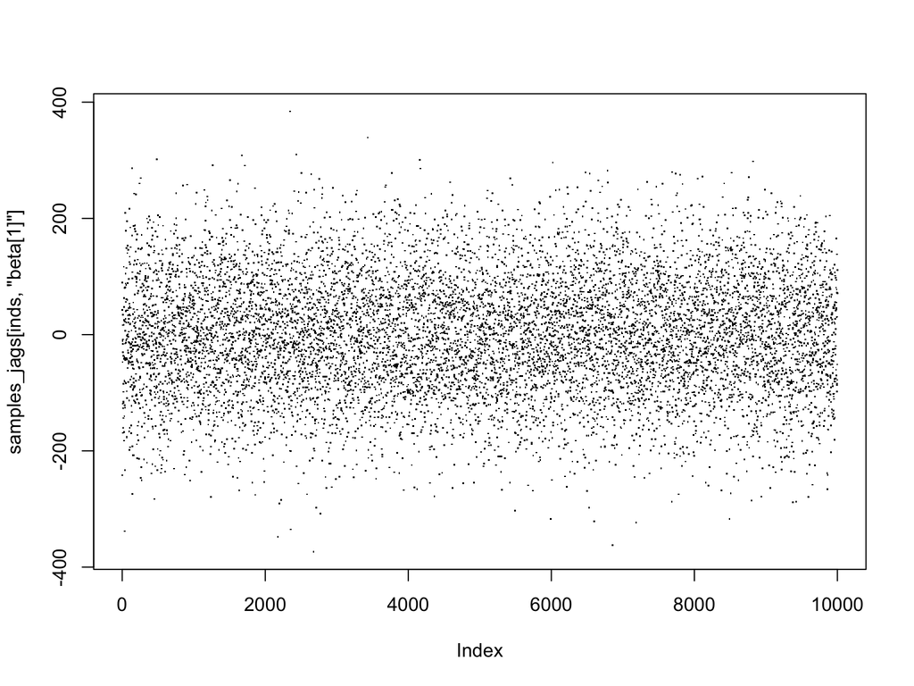

```r
inds <- 50001:60000 ## Look at arbitrary 10000 iterations
plot(samples_jags[inds,'beta[1]'], pch = '.')
```

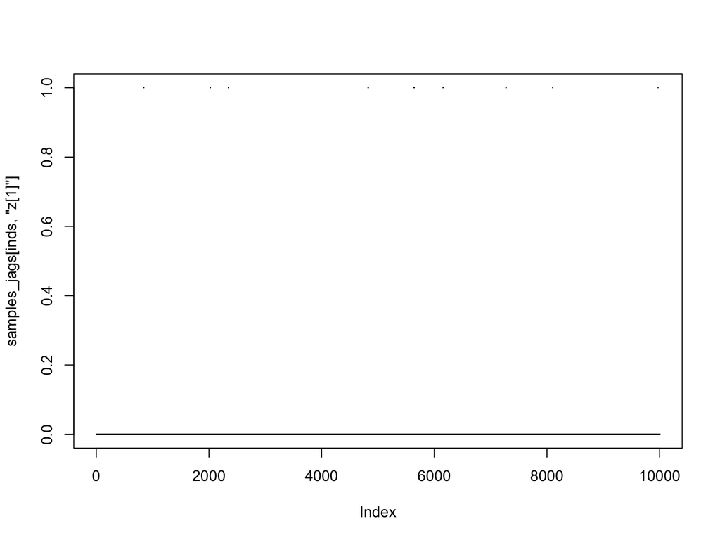

```r
plot(samples_jags[inds,'z[1]'], pch = '.')
```

### Look at beta[4]

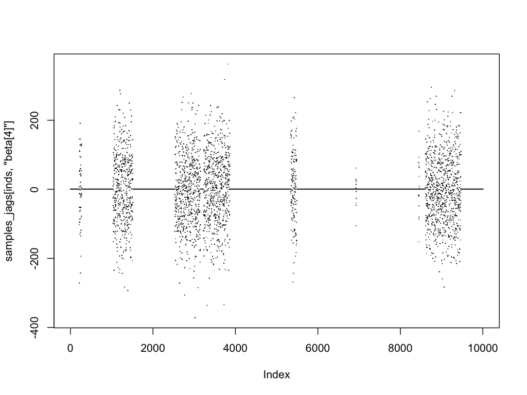

```r
plot(samples_jags[inds,'beta[4]'], pch = '.')
```

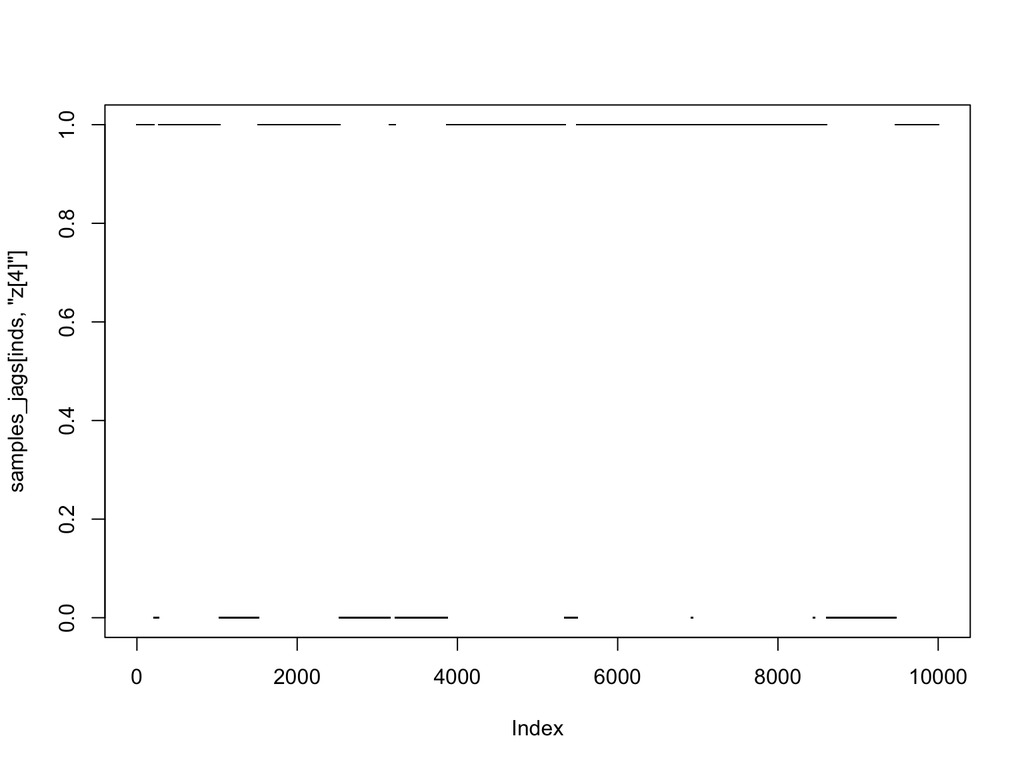

```r
plot(samples_jags[inds,'z[4]'], pch = '.')
```

### Look at beta[5]

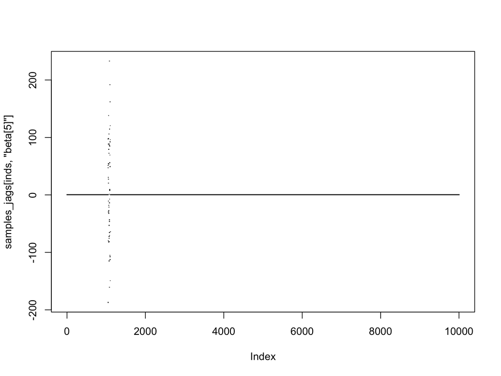

```r
plot(samples_jags[inds,'beta[5]'], pch = '.')
```

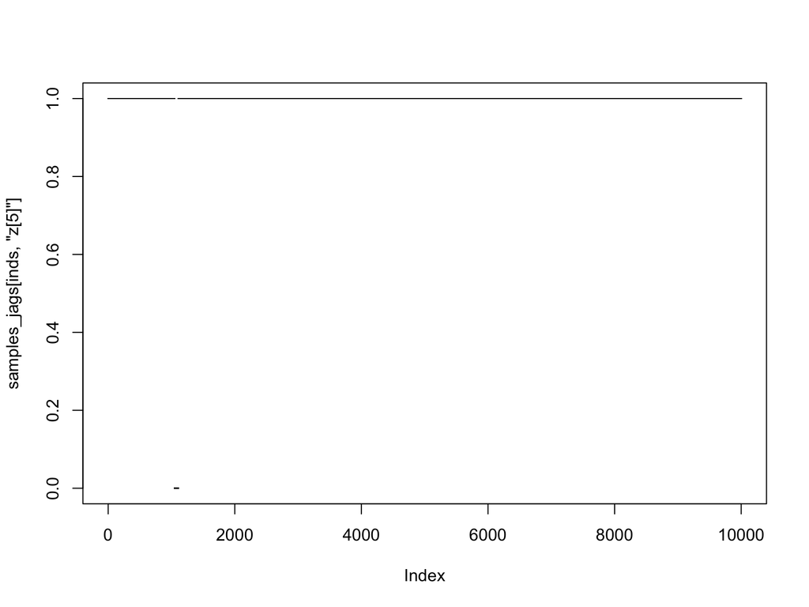

```r
plot(samples_jags[inds,'z[5]'], pch = '.')
```

### Look at posterior inclusion probabilities for each `beta[i]`

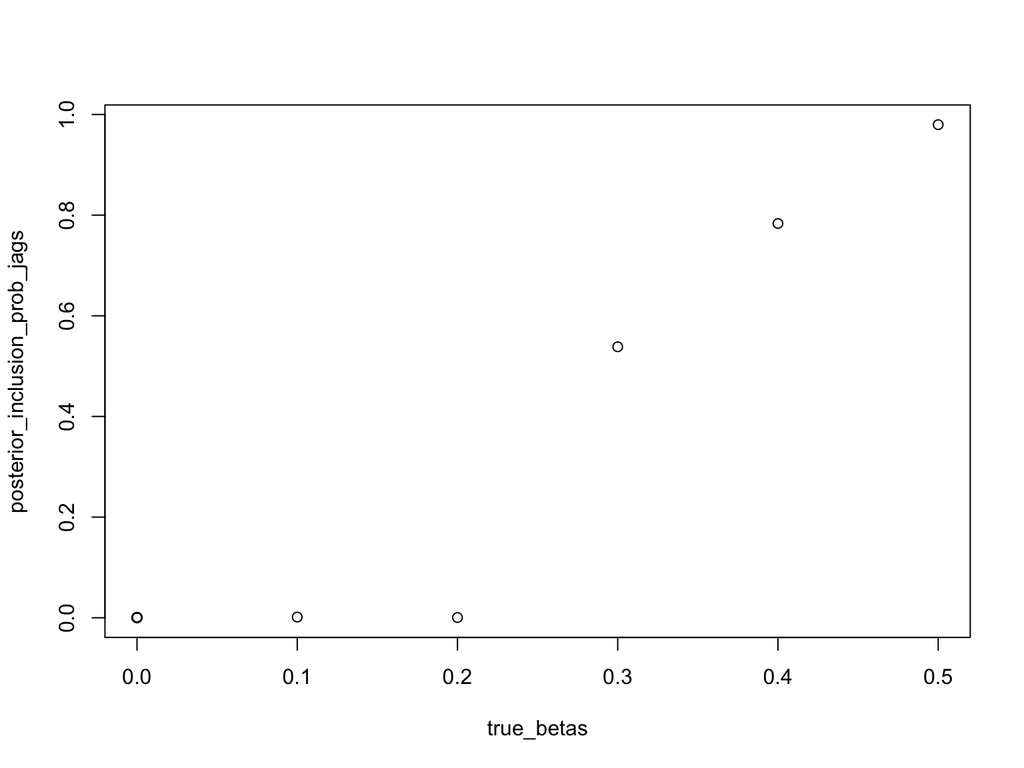

```r
zCols <- grep("z\\[", colnames(samples_jags))
posterior_inclusion_prob_jags <- colMeans(samples_jags[,zCols])
plot(true_betas, posterior_inclusion_prob_jags)
```

### Look at posterior inclusion probability, `psi`

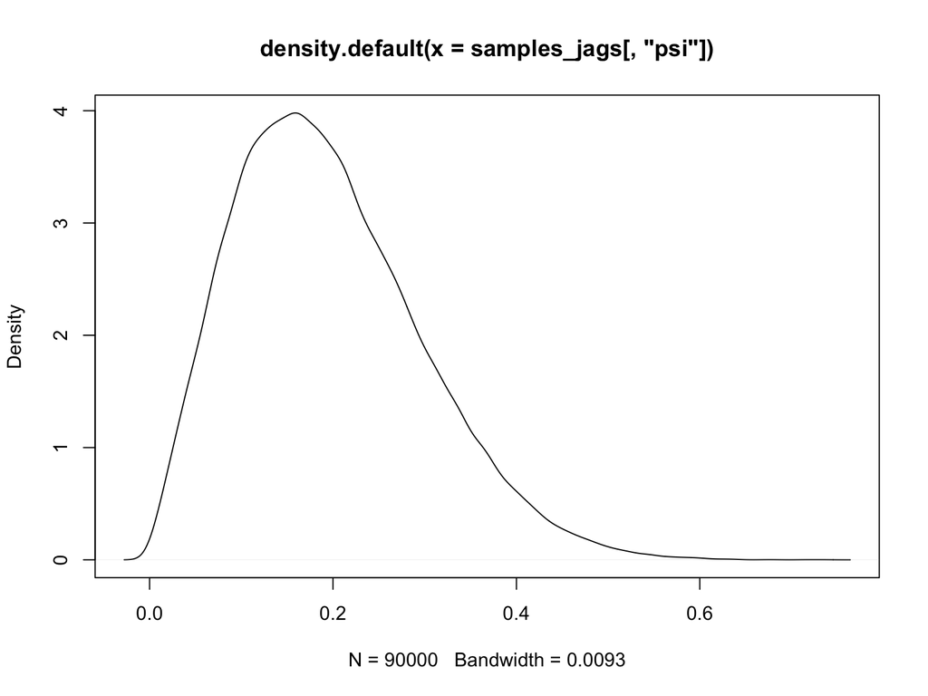

```r
plot(density(samples_jags[,'psi']))
```

# Summary of JAGS results

- Marginal posterior inclusion probabilities look reasonable.
- Mixing over `z[i]`s is slow. For shorter runs, we would not be happy with mixing.
- When `z[i]` is 0, `beta[i]`s follow their priors, until they hit values that allow `z[i]` of 1 to be accepted.
- JAGS uses slice samplers.
- I think a common work-around is to use informative priors. That means changing your model to help the MCMC implementation.

# Look at nimble results with default samplers.

```r
MCMCconf <- configureMCMC(lmModel)
MCMCconf$addMonitors('z')
```

```
## thin = 1: psi, sigma, beta, z
```

```r
MCMC <- buildMCMC(MCMCconf)
ClmModel <- compileNimble(lmModel)
```

```
## compiling... this may take a minute. Use 'showCompilerOutput = TRUE' to see C++ compilation details.
```

```
## compilation finished.
```

```r
CMCMC <- compileNimble(MCMC, project = lmModel, resetFunctions = TRUE)
```

```
## compiling... this may take a minute. Use 'showCompilerOutput = TRUE' to see C++ compilation details.
## compilation finished.
```

```r
set.seed(100)
system.time(samples_nimble <- runMCMC(CMCMC, niter = 100000, nburnin = 10000))
```

```
## running chain 1...
```

```
## |-------------|-------------|-------------|-------------|
## |-------------------------------------------------------|
```

```
##    user  system elapsed
##  22.346   0.060  22.447
```

# Look at default nimble results

### Look at beta[1]

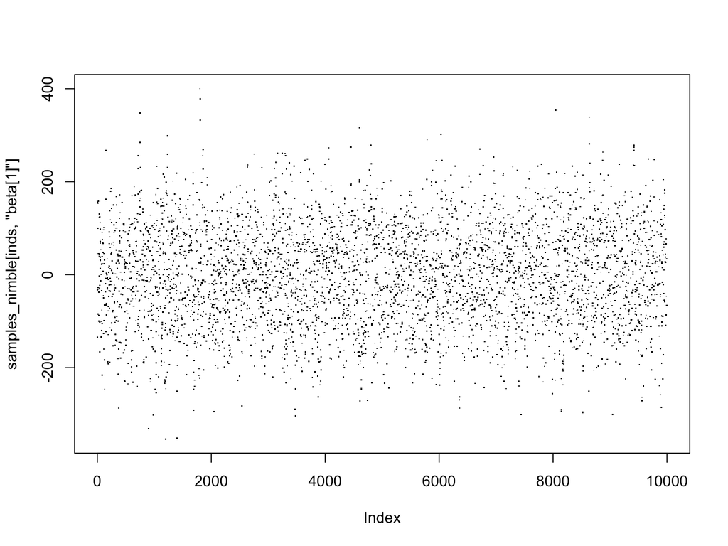

```r
inds <- 50001:60000 ## Look at arbitrary 10000 iterations
plot(samples_nimble[inds,'beta[1]'], pch = '.')
```

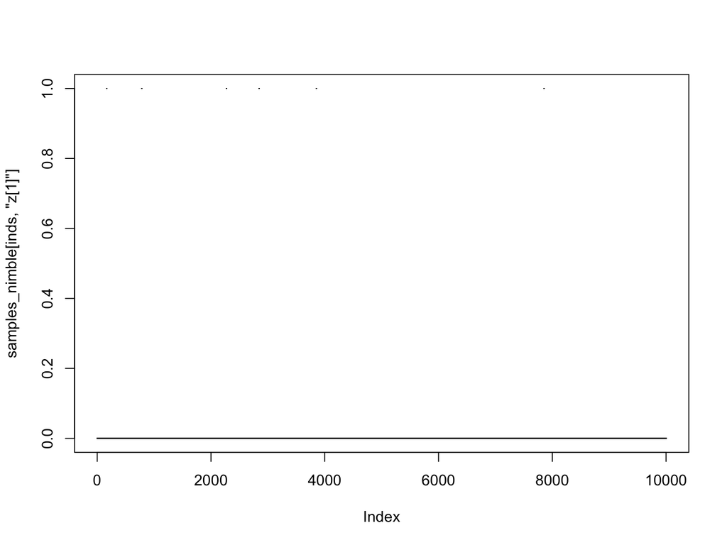

```r
plot(samples_nimble[inds,'z[1]'], pch = '.')
```

### Look at beta[4]

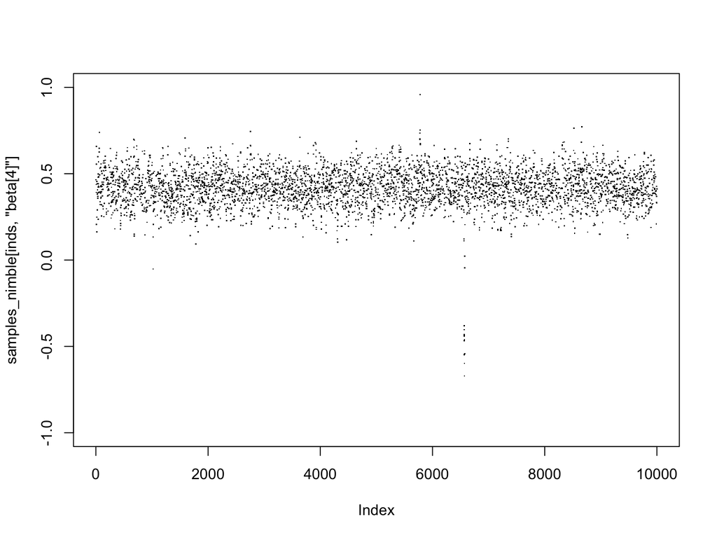

```r
plot(samples_nimble[inds,'beta[4]'], pch = '.', ylim = c(-1, 1))
```

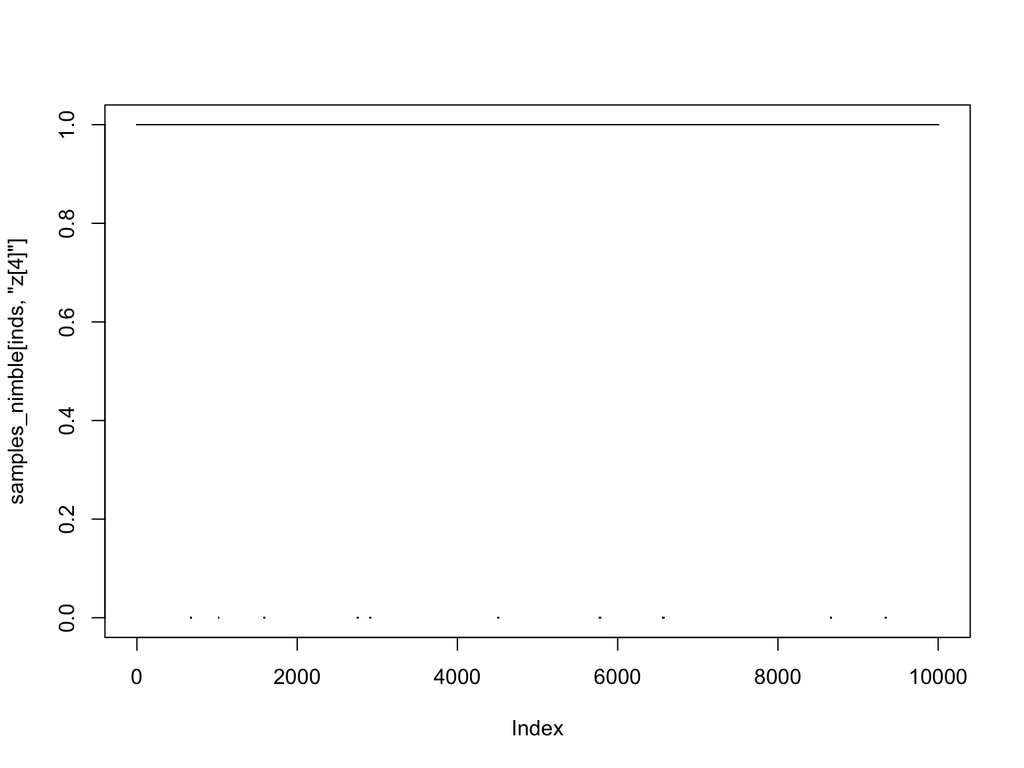

```r
plot(samples_nimble[inds,'z[4]'], pch = '.')
```

### Look at beta[5]

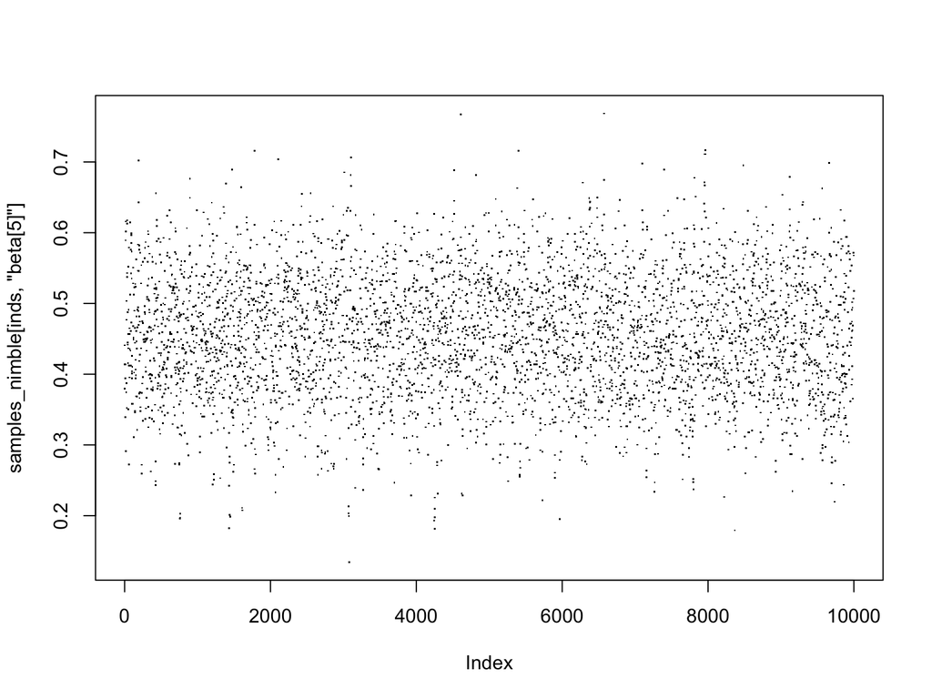

```r
plot(samples_nimble[inds,'beta[5]'], pch = '.')
```

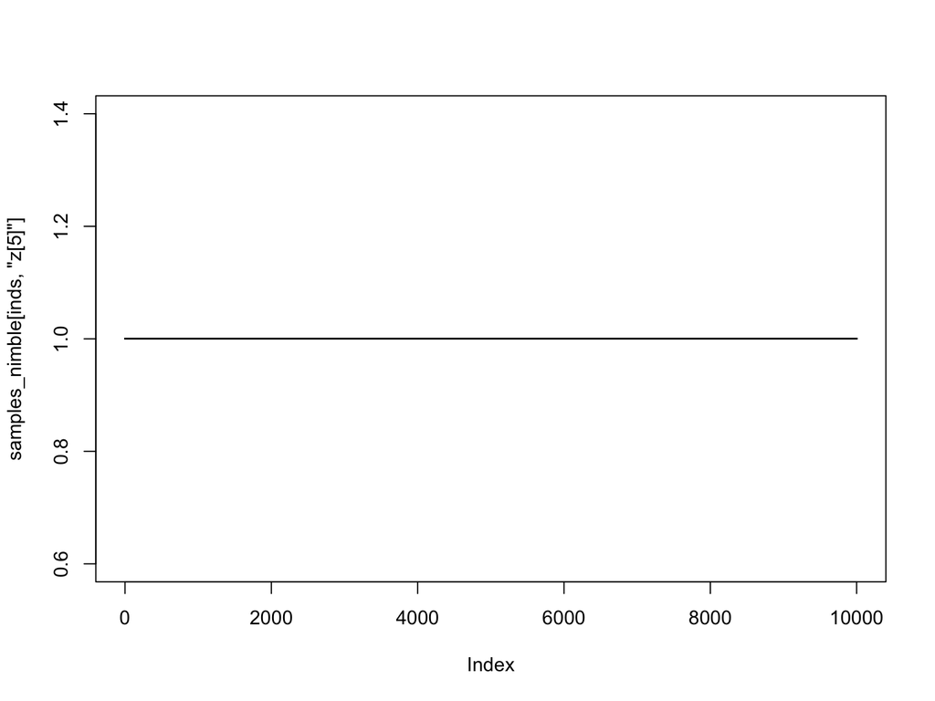

```r
plot(samples_nimble[inds,'z[5]'], pch = '.')
```

### Look at posterior inclusion probabilities from each `beta[i]`

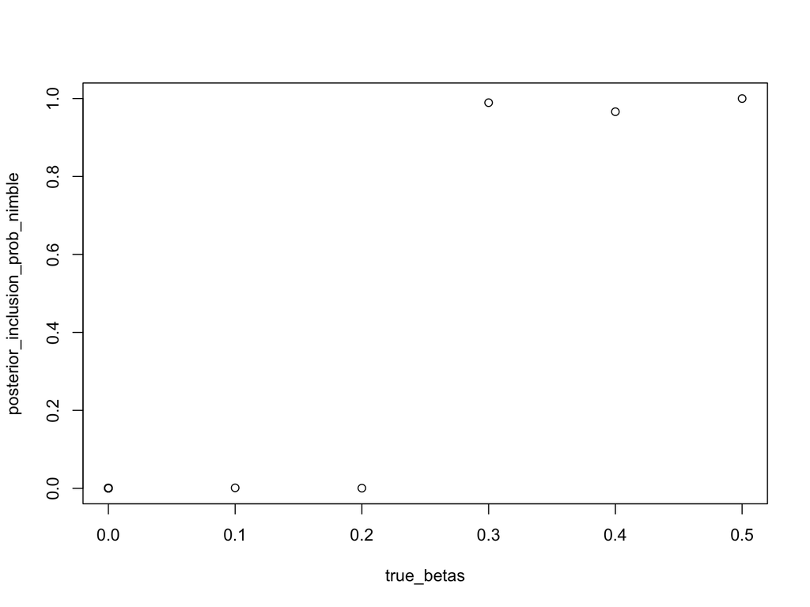

```r
zCols <- grep("z\\[", colnames(samples_nimble))
posterior_inclusion_prob_nimble <- colMeans(samples_nimble[,zCols])
plot(true_betas, posterior_inclusion_prob_nimble)
```

### Look at posterior inclusion probability, `psi`

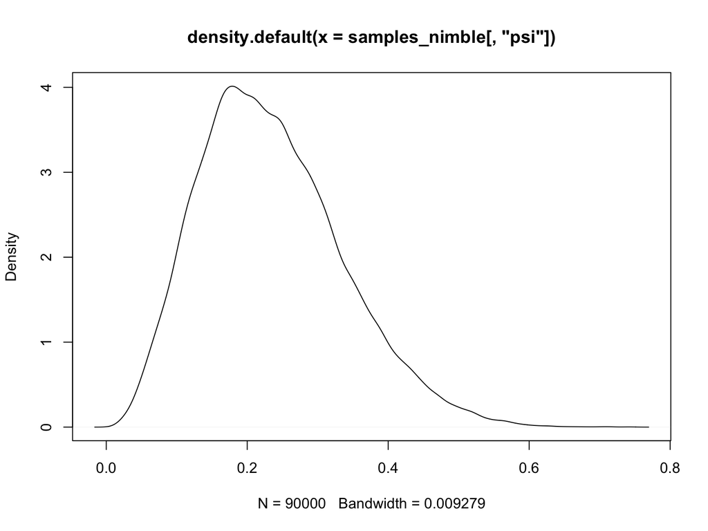

```r
plot(density(samples_nimble[,'psi']))
```

# Summary of results from default nimble

- Different from (probably worse that) JAGS.
- `beta[3]`, `beta[4]` and `beta[5]` are included almost always (posterior probability near 1).
- When `z[i] = 0`, the corresponding `beta[i]` will start following its **prior**. It may wander far away from reasonable values, with either fast or slow mixing (depending on the situation).

# Summary of JAGS and default nimble

### Wasteful computation (a secondary issue)

- When `z[i] = 0`, we’d like to not be wasting computation on `beta[i]`.

# Solution: Reversible Jump MCMC

- RJMCMC is a method for sampling across different models.
- Specifically it is about sampling between different numbers of dimensions.
- We don’t change the actual nimble model object, but we turn on and off which dimensions are sampled.
- Implementation, like all samplers, is written using `nimbleFunction`s.

# RJMCMC for variable selection in nimble

- Update an MCMC configuration to use RJMCMC.

```r
# make a new copy of the model to be totally independent
lmModel2 <- lmModel$newModel(replicate = TRUE)
```

```
## checking model sizes and dimensions... This model is not fully initialized. This is not an error. To see which variables are not initialized, use model$initializeInfo(). For more information on model initialization, see help(modelInitialization).
```

```r
MCMCconfRJ <- configureMCMC(lmModel2)
MCMCconfRJ$addMonitors('z')
```

```
## thin = 1: psi, sigma, beta, z
```

```r
configureRJ(MCMCconfRJ,
            targetNodes = 'beta',
            indicatorNodes = 'z',
            control = list(mean = 0, scale = .2))
MCMCRJ <- buildMCMC(MCMCconfRJ)
```

# Run the RJMCMC

```r
ClmModel2 <- compileNimble(lmModel2)
```

```
## compiling... this may take a minute. Use 'showCompilerOutput = TRUE' to see C++ compilation details.
```

```
## compilation finished.
```

```r
CMCMCRJ <- compileNimble(MCMCRJ, project = lmModel2)
```

```
## compiling... this may take a minute. Use 'showCompilerOutput = TRUE' to see C++ compilation details.
## compilation finished.
```

```r
set.seed(100)
system.time(samples_nimble_RJ <- runMCMC(CMCMCRJ, niter = 100000, nburnin = 10000))
```

```
## running chain 1...
```

```
## |-------------|-------------|-------------|-------------|
## |-------------------------------------------------------|
```

```
##    user  system elapsed
##  13.717   0.045  13.776
```

# Look at RJMCMC results

### Look at beta[1]

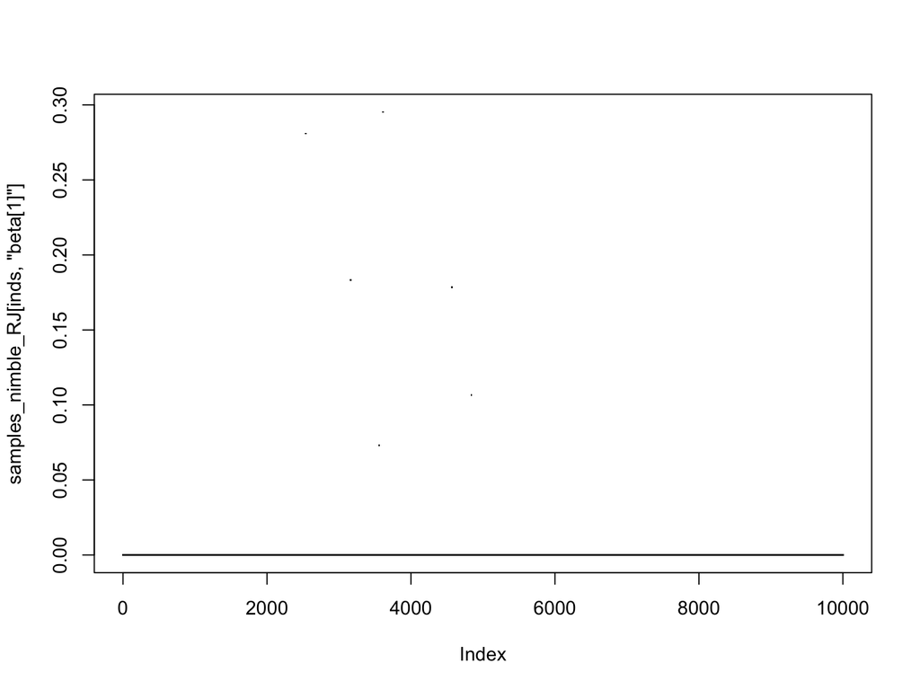

```r
inds <- 50001:60000
plot(samples_nimble_RJ[inds,'beta[1]'], pch = '.')
```

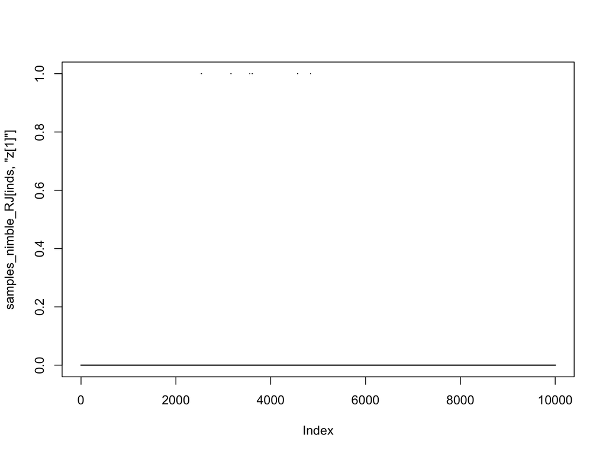

```r
plot(samples_nimble_RJ[inds,'z[1]'], pch = '.')
```

### Look at beta[4]

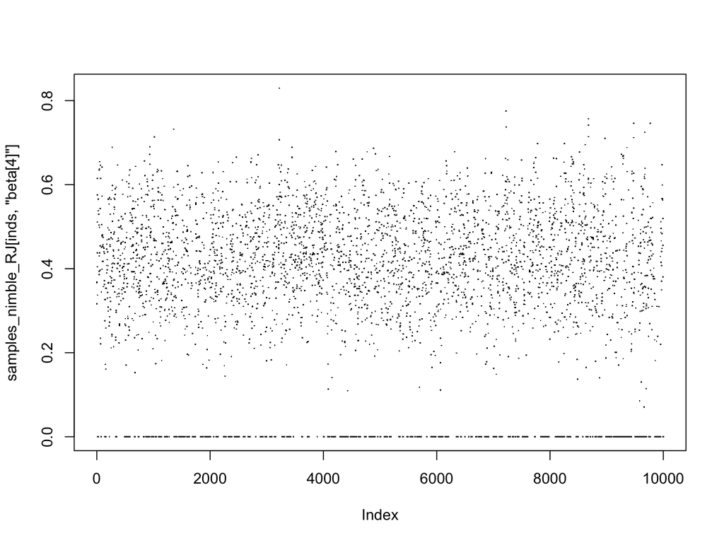

```r
plot(samples_nimble_RJ[inds,'beta[4]'], pch = '.')
```

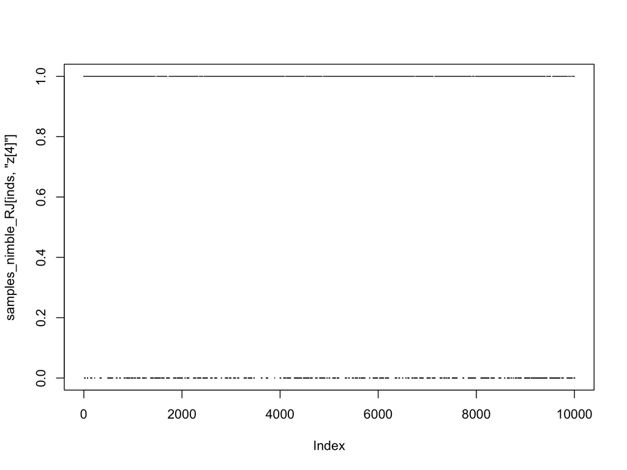

```r
plot(samples_nimble_RJ[inds,'z[4]'], pch = '.')
```

### Look at beta[5]

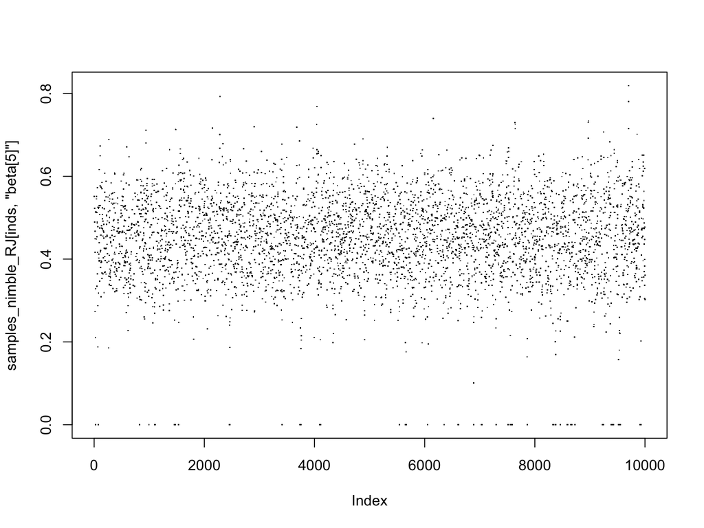

```r
plot(samples_nimble_RJ[inds,'beta[5]'], pch = '.')
```

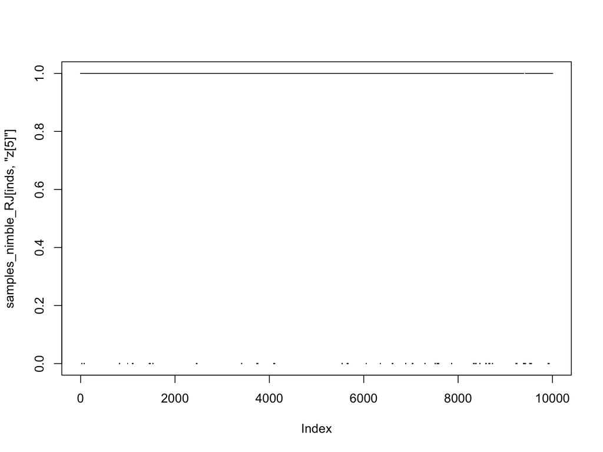

```r
plot(samples_nimble_RJ[inds,'z[5]'], pch = '.')
```

### Look at posterior inclusion probabilities of each `beta[i]`

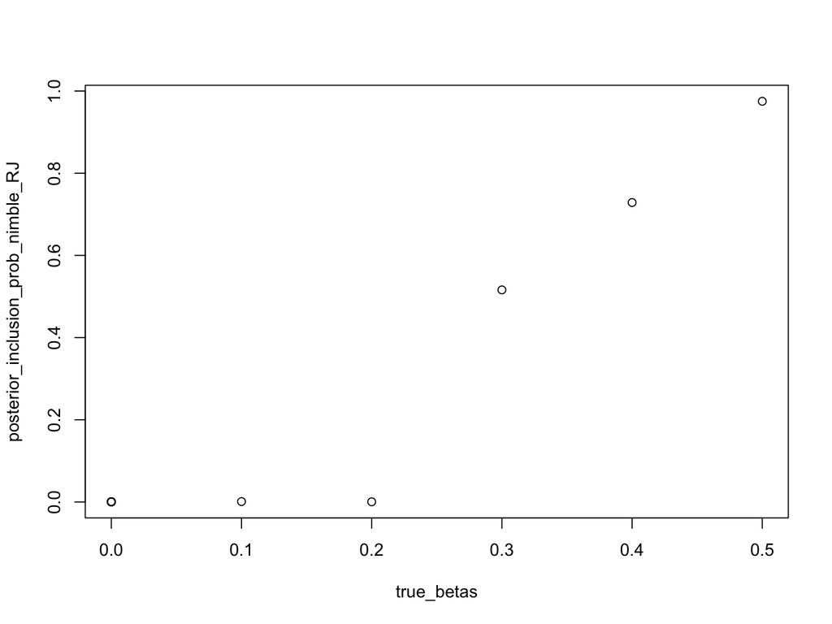

```r
zCols <- grep("z\\[", colnames(samples_nimble_RJ))
posterior_inclusion_prob_nimble_RJ <- colMeans(samples_nimble_RJ[,zCols])
plot(true_betas, posterior_inclusion_prob_nimble_RJ)
```

### Look at posterior inclusion probability, `psi`

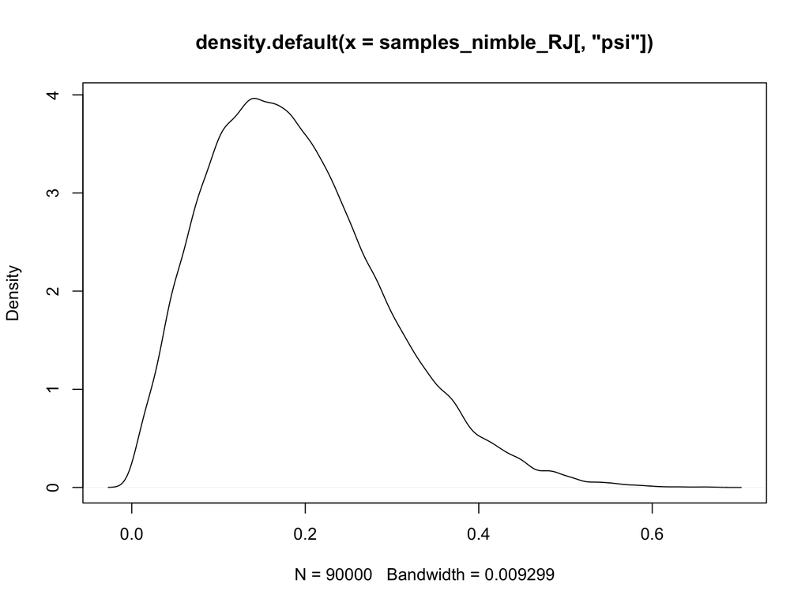

```r
plot(density(samples_nimble_RJ[,'psi']))
```

# Summary of RJMCMC

- Mixing was much better.
- Result looks intuitively more sensible.
- Adaptation for coefficient samplers only occurs when the coefficient is “in the model”.
- Run time was much faster than default nimble, which was faster than JAGS. Magnitudes will depend on specific problems (how often `z[i]` are 0.)
- Tuning parameter of RJ proposal scale (sd) must be chosen.